# Moby Dick Text Analysis

William Lovejoy

4/8/2022

## Importing and Bigrams

The text for the book will be fetched from the gutenberg library and loaded into R.

```r
moby <- gutenberg_download(15, mirror = "https://gutenberg.pglaf.org/")
```

To start, I split the text into it’s bigrams, seperated them and removed bigrams where either word was a stop-word (such as: the, a, is, are, etc.). I removed all NA’s, counted the number of times each bigram appeared, and then reunited the words.

```r
moby_bigrams <- moby %>%
  unnest_tokens(bigram, text, token = "ngrams", n = 2)

moby_separate <- moby_bigrams %>%
  separate(bigram, c("word1", "word2"), sep = " ")

moby_filtered <- moby_separate %>%
  filter(!word1 %in% stop_words$word,
         !word2 %in% stop_words$word,
         is.na(word1) == FALSE,
         is.na(word2) == FALSE)

moby_counts <- moby_filtered %>%
  count(word1, word2, sort = TRUE)

moby_united <- moby_counts %>%
  unite(bigram, word1, word2, sep = " ")

head(moby_united)
```

```
## # A tibble: 6 x 2
##   bigram           n
##   <chr>        <int>
## 1 sperm whale    133
## 2 white whale     87
## 3 moby dick       78
## 4 captain ahab    56
## 5 mast head       49
## 6 mast heads      38
```

Using the bind_tf_idf() function, I calculated the term frequency for each bigram and created a new tibble for the data. I passed that data to ggplot so we can see which bigrams were the most frequent, and by how much.

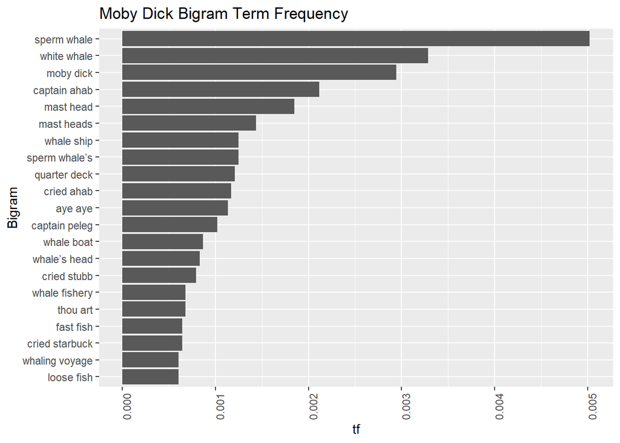

```r
moby_bigram_idf <-  moby_united %>%
  mutate(book = "Moby Dick") %>%
  bind_tf_idf(bigram, book, n)

moby_bigram_idf %>%
  subset(n > 15) %>%
  ggplot(aes(reorder(bigram, tf), y = tf)) + geom_col() +
  coord_flip() + theme(axis.text.x = element_text(angle = 90)) +
  xlab("Bigram") + ylab("tf") + labs(title = "Moby Dick Bigram Term Frequency")
```

## Sentiments

Going back to the source text, we’ll separate the data on individual words rather than bigrams. We’ll also make a quick wordcloud (removing stop-words) of the text to see which singular words are the most common.

```r
moby_tidy <- moby %>%
  mutate(linenumber = row_number(),
         chapter = cumsum(str_detect(text,
                                     regex("^chapter [\\divxlc]",
                                           ignore_case = TRUE)))) %>%
  ungroup()

tidy_moby <- moby_tidy %>%
  unnest_tokens(word, text)

head(tidy_moby)
```

```
## # A tibble: 6 x 4
##   gutenberg_id linenumber chapter word
##          <int>      <int>   <int> <chr>
## 1           15          1       0 moby
## 2           15          1       0 dick
## 3           15          3       0 or
## 4           15          5       0 the
## 5           15          5       0 whale
## 6           15          7       0 by
```

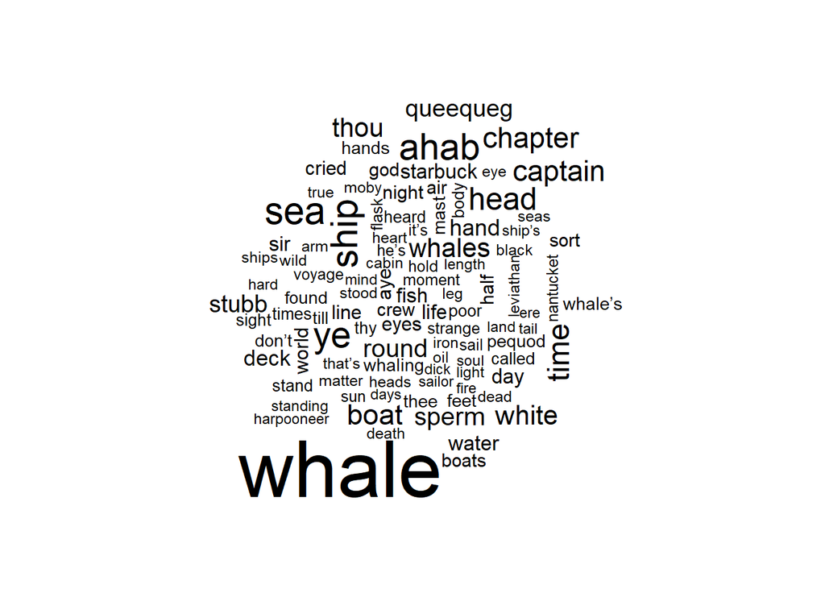

```r
tidy_moby %>%
  anti_join(stop_words) %>%
  count(word) %>%
  with(wordcloud(word, n, max.words = 100))
```

As expected, “whale” is the most common word in the book.

Now I find the sentiments for the individual words in the text using Bing et al. I index the book based off of line number and find the gross assigned sentiment for each section. I then used ggplot to look at the overall positivity vs. negativity of the book as the story progresses.

```r
moby_sentiment <- tidy_moby %>%
  inner_join(get_sentiments("bing")) %>%
  count(index = linenumber %/% 80, sentiment) %>%
  pivot_wider(names_from = sentiment, values_from = n, values_fill = 0) %>%
  mutate(sentiment = positive - negative)
```

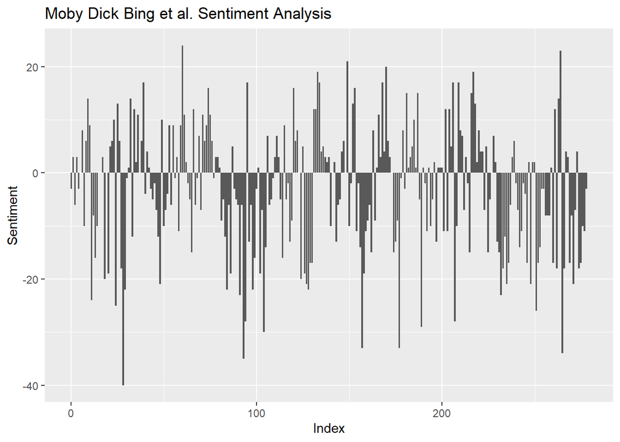

```r
ggplot(moby_sentiment, aes(x = index, y = sentiment)) +
  geom_col(show.legend = FALSE) + xlab("Index") + ylab("Sentiment") +
  labs(title = "Moby Dick Bing et al. Sentiment Analysis")
```

We can see that the story is, overall, largely negative. It has far more words with negative sentiments than positive ones, and even ends on a sorrowful note when Captain Ahab is entangled in his harpoon line and dragged down by Moby Dick along with the remains of his ship, the Pequod.